# Quality control

Jullien Flynn

2017-01-20

Load necessary packages:

Quality control steps required: * number of reads with kmers/total number of reads * raw data before normalization , compare to normalized data * compare technical replicates

# Reads with kmers per sample

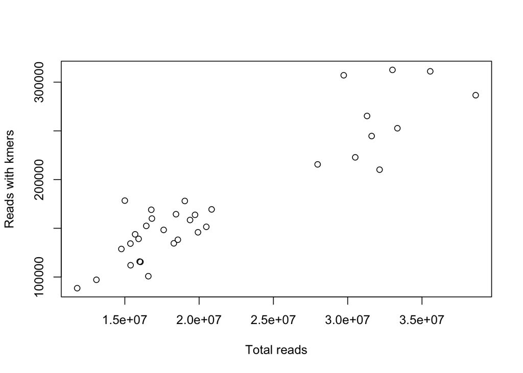

```r
kmer_reads <- read.csv("~/Documents/FirstRotation-Andy/kmer_reads.csv")
# last row is the total, get rid of it
kmer_reads <- kmer_reads[1:nrow(kmer_reads)-1,]
plot(x=kmer_reads$Total.reads, y=kmer_reads$kmer.reads, xlab="Total reads", ylab="Reads with kmers")
```

```r
# top cluster is the second library prep, which has higher depth but the same proportion of reads with kmers as the first library.
```

# Compare before and after normalization

Check correlation with kmer abundance to read depth.

```r
# import raw, un-normalized data
daphniakmers <- read.delim("~/Documents/FirstRotation-Andy/daphniakmer.rep.compiled.txt")
# name the rows as the names of the lines
file_names <- as.vector(daphniakmers$lines)
file_names <- sapply(strsplit(file_names, "\\."), '[', 1)
rownames(daphniakmers) <- file_names
# now get rid of the column that has the file name
daphniakmers[,1] <- NULL
# the columns (kmers) by their mean abundance
means <- colMeans(daphniakmers)
index.orders <- order(means, decreasing=T)
daphniakmers <- daphniakmers[,order(means, decreasing=T)]
# remove the total bp column and the poly-N columns
daphniakmers$total_bp <- NULL
daphniakmers$N.N <- NULL

# change the colnames to not show the reverse complement
kmer.labels <- sapply(strsplit(colnames(daphniakmers), "\\."), '[', 1)
colnames(daphniakmers) <- kmer.labels

# Get rowSums for each sample
raw_counts <- rowSums(daphniakmers)
raw_counts
```

```
##     C01     C02     C03     C06     C07     C08     C12     C13     C14
## 1668686 1665537 2312156 2395053 1868305 1919400 2451043 2274752 2264170
##     C16     C17     C18     C20     C21     C23     C24     C25     C27
## 2455913 2538365 2122961 2472070 2327822 2805247 2079200 2022324 3278286
##     C34     C35     C36     C37     C38     C39     C40     C43     C44
## 2236751 1679066 2238860 1717545 2290283 1577063 1961213 2719869 1757944
##     C49     CC3     CC4     CC6     CC7     CC8     CC9
## 2511616 2469733 2326923 2662261 3021407 2400616 2988614
```

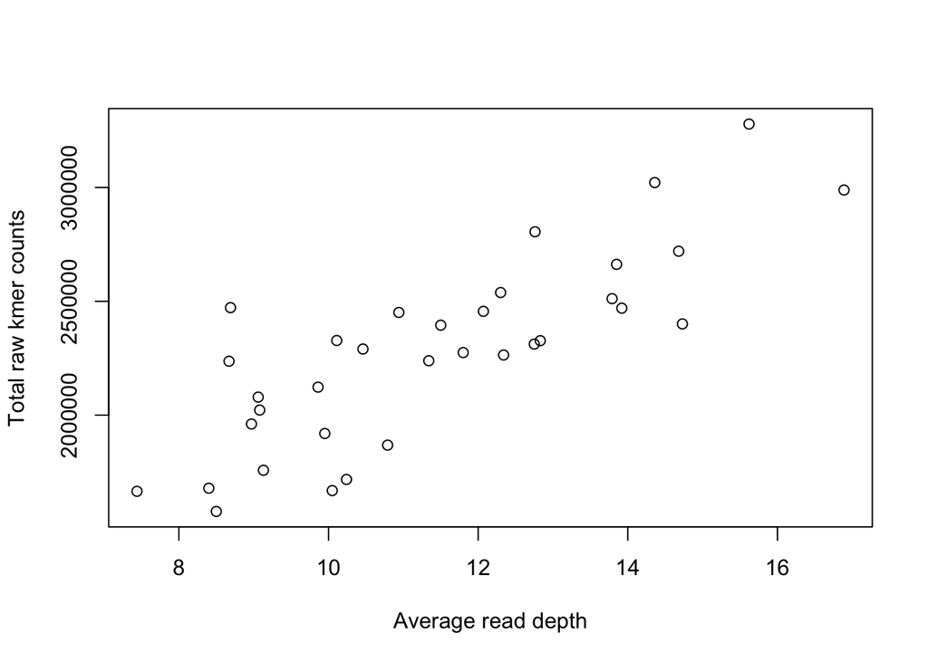

```r
# import read depth (calculated from GATK DepthOf Coverage)
mapdp <- read.table("~/Documents/mapdp.txt", header=F)
mapdp <- as.vector(mapdp[, 1])

# plot the raw total kmer counts against the average read depth
plot(x=mapdp, y=raw_counts, xlab="Average read depth", ylab="Total raw kmer counts")
```

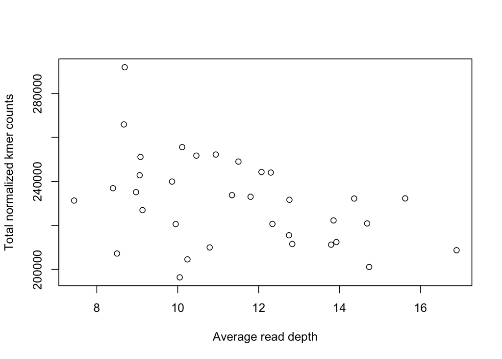

```r
# import data normalized by depth and GC-content
daphniakmers_normalized_w_techrep <- read.csv("~/Documents/FirstRotation-Andy/daphniakmers_corrected_bins3_Jan7.csv")
# process it
file_names <- as.vector(daphniakmers_normalized_w_techrep$X)
file_names <- sapply(strsplit(file_names, "\\."), '[', 1)
rownames(daphniakmers_normalized_w_techrep) <- file_names
# now get rid of the column that has the file name
daphniakmers_normalized_w_techrep[,1] <- NULL
# the columns (kmers) by their mean abundance
means <- colMeans(daphniakmers_normalized_w_techrep)
index.orders <- order(means, decreasing=T)
daphniakmers_normalized_w_techrep <- daphniakmers_normalized_w_techrep[,order(means, decreasing=T)]
# remove the total bp column and the poly-N columns
daphniakmers_normalized_w_techrep$total_bp <- NULL
daphniakmers_normalized_w_techrep$N.N <- NULL

daphniakmers_normalized_w_techrep <- as.matrix(daphniakmers_normalized_w_techrep)
## need to convert to matrix
daphniakmers_normalized_w_techrep <- as.matrix(daphniakmers_normalized_w_techrep)
# don't deal with the technical replicates for now
techreps <- c("C001", "C035")
daphniakmers_normalized <- daphniakmers_normalized_w_techrep[!rownames(daphniakmers_normalized_w_techrep) %in% techreps, ]
total_normalized_counts <- rowSums(daphniakmers_normalized)

# plot this now
plot(x=mapdp, y=total_normalized_counts, xlab="Average read depth", ylab="Total normalized kmer counts")
```

There was a positive linear relationship between read depth and kmer counts before normalization, as to be expected.  
After normalizing, this positive relationship is no longer apparent. A slight negative relationship is likely because the population isolates had higher read depth, and they had less kmer content (which we argue is due to selection, see manuscript).

# Process this data without technical replicates and get summaries

```r
common.kmer.indexes <- c()
for (i in 1:ncol(daphniakmers_normalized)) {
  if (mean(daphniakmers_normalized[,i])>=100) {
    common.kmer.indexes <- c(common.kmer.indexes, i)
  }
}
names(common.kmer.indexes) <- colnames(daphniakmers_normalized)[common.kmer.indexes]
common.kmer.names <- colnames(daphniakmers_normalized)[common.kmer.indexes]

length(common.kmer.indexes)
```

```
## [1] 39
```

```r
Calc_GC_content <- function (kmer_string) {
  string <- BString(kmer_string)
  gc.content <- c(letterFrequency(string, letters=c("CG"), as.prob=F)/(length(string)))
  return(gc.content)
}

common.kmer.gc <- sapply(common.kmer.names, Calc_GC_content)
length(common.kmer.gc)
```

```
## [1] 39
```

```r
# get rid of the dot before the GC in the name
names(common.kmer.gc) <- common.kmer.names
```

# Compare technical replicates

```r
C35.index <- which(rownames(daphniakmers_normalized_w_techrep)=="C35")
C01.index <- which(rownames(daphniakmers_normalized_w_techrep)=="C01")
C001.index <- which(rownames(daphniakmers_normalized_w_techrep)=="C001")
C035.index <- which(rownames(daphniakmers_normalized_w_techrep)=="C035")

C01.comparison_common.kmers <- as.vector(daphniakmers_normalized_w_techrep[C01.index, common.kmer.indexes]) / as.vector(daphniakmers_normalized_w_techrep[C001.index, common.kmer.indexes])

names(C01.comparison_common.kmers) <- colnames(daphniakmers_normalized_w_techrep)[common.kmer.indexes]

C01.comparison_common.kmers
```

```
##                    A                AACCT ACGCCAGAGCACGCCAGTGC
##            0.7202090            1.0148803            0.9303448
##                AATGG                  AGG           AACCTTGGCG
##            1.0531954            1.2727624            0.6512991
##                AACAG                    C           ACGCCAGAGC
##            1.0907915            1.5870234            0.9141085
##         AAAAATAACAAC                  AAG           ACGCCAGTGC
##            0.8389445            0.8377687            0.8947052
##               AGCCTG    AATCTGGAATGGAATGG        AAGCCAGTGCAGC
##            0.9334975            0.8842399            1.1049069
##                 AAAG AAGAGCACGCCAGTGCACGC             AAAATAGG
##            0.6344086            1.0325866            0.8321918
##                ACAGC                AAAAG                   AG
##            0.6968577            0.6291667            0.9827586
##                AAGAG                 ATCC                  AAC
##            1.0502959            0.9610028            1.0157729
##           ACAGGAGAGC                   AC               AAGGAG
##            1.0869565            0.8098160            0.9629630
## AAGTGCACGCCAGAGCACGC           ACAGGAGACC    AAAAAGAAGATAGTAGG
##            0.9382022            1.0430108            0.7622951
##               AACAAG              AAATAGG ACACCGAGGCTCCAGCTACT
##            1.1217949            0.7105263            1.0227273
## AATGCACGCCAGAGCACGCC           AATGCACGCC ACACCGAGTCTCCAGCTACT
##            0.8644068            0.6511628            1.0612245
##           AACGGTACGG                  ACT AATTCACACCAGAGCACGCC
##            1.6349206            0.9650350            0.7816092
```

```r
mean(C01.comparison_common.kmers)
```

```
## [1] 0.9482146
```

```r
sd(C01.comparison_common.kmers)
```

```
## [1] 0.2193982
```

```r
C35.comparison_common.kmers <- as.vector(daphniakmers_normalized_w_techrep[C35.index, common.kmer.indexes]) / as.vector(daphniakmers_normalized_w_techrep[C035.index, common.kmer.indexes])

names(C35.comparison_common.kmers) <- colnames(daphniakmers_normalized_w_techrep)[common.kmer.indexes]

C35.comparison_common.kmers
```

```
##                    A                AACCT ACGCCAGAGCACGCCAGTGC
##            0.9203001            1.0859405            0.9860557
##                AATGG                  AGG           AACCTTGGCG
##            0.8877838            1.2213355            1.1199940
##                AACAG                    C           ACGCCAGAGC
##            1.2956589            1.7744722            0.9785505
##         AAAAATAACAAC                  AAG           ACGCCAGTGC
##            0.9826941            0.8781621            0.8621103
##               AGCCTG    AATCTGGAATGGAATGG        AAGCCAGTGCAGC
##            1.0297619            1.0551905            1.5239669
##                 AAAG AAGAGCACGCCAGTGCACGC             AAAATAGG
##            0.9566360            1.0117878            0.7833066
##                ACAGC                AAAAG                   AG
##            1.4664948            1.0945946            1.1435080
##                AAGAG                 ATCC                  AAC
##            1.0964187            1.1641791            1.1130742
##           ACAGGAGAGC                   AC               AAGGAG
##            1.0982143            1.1205674            0.8932806
## AAGTGCACGCCAGAGCACGC           ACAGGAGACC    AAAAAGAAGATAGTAGG
##            0.9842105            1.0000000            0.7625418
##               AACAAG              AAATAGG ACACCGAGGCTCCAGCTACT
##            1.0222222            0.7372881            1.3879310
## AATGCACGCCAGAGCACGCC           AATGCACGCC ACACCGAGTCTCCAGCTACT
##            1.0454545            0.9795918            1.1121495
##           AACGGTACGG                  ACT AATTCACACCAGAGCACGCC
##            0.8155340            1.2336449            0.9268293
```

```r
mean(C35.comparison_common.kmers)
```

```
## [1] 1.065421
```

```r
sd(C35.comparison_common.kmers)
```

```
## [1] 0.2108703
```

See if deviations are consistently related to GC content

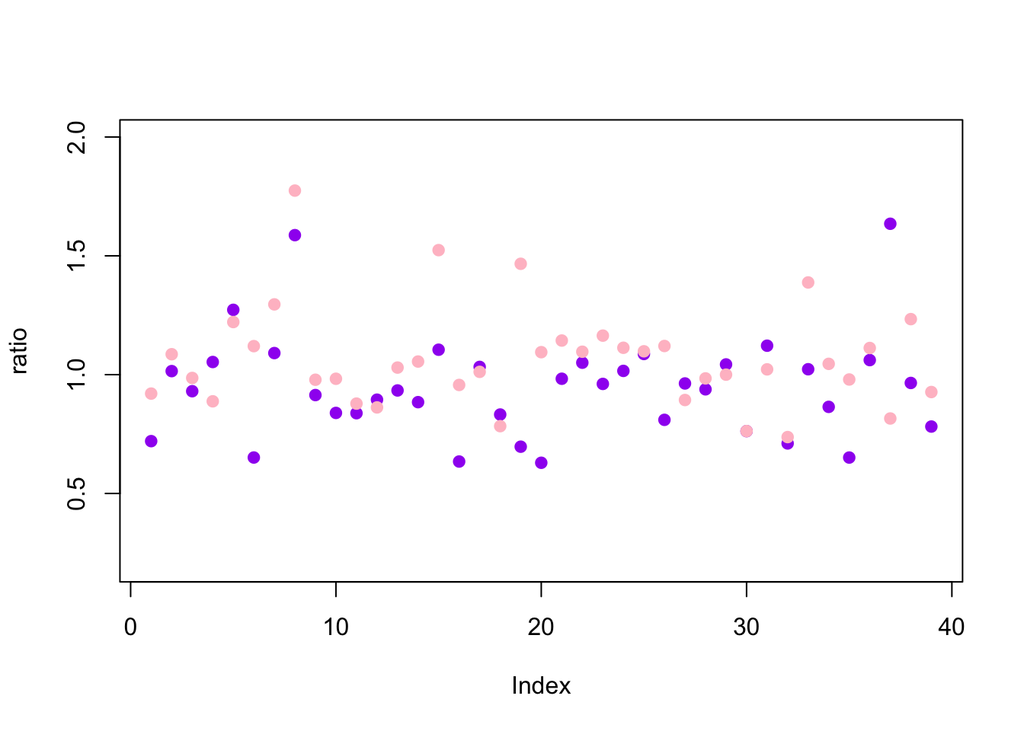

```r
plot(C01.comparison_common.kmers, pch=19, col="purple", ylim=c(0.2, 2) , ylab="ratio")
points(C35.comparison_common.kmers, pch=19, col="pink")
```

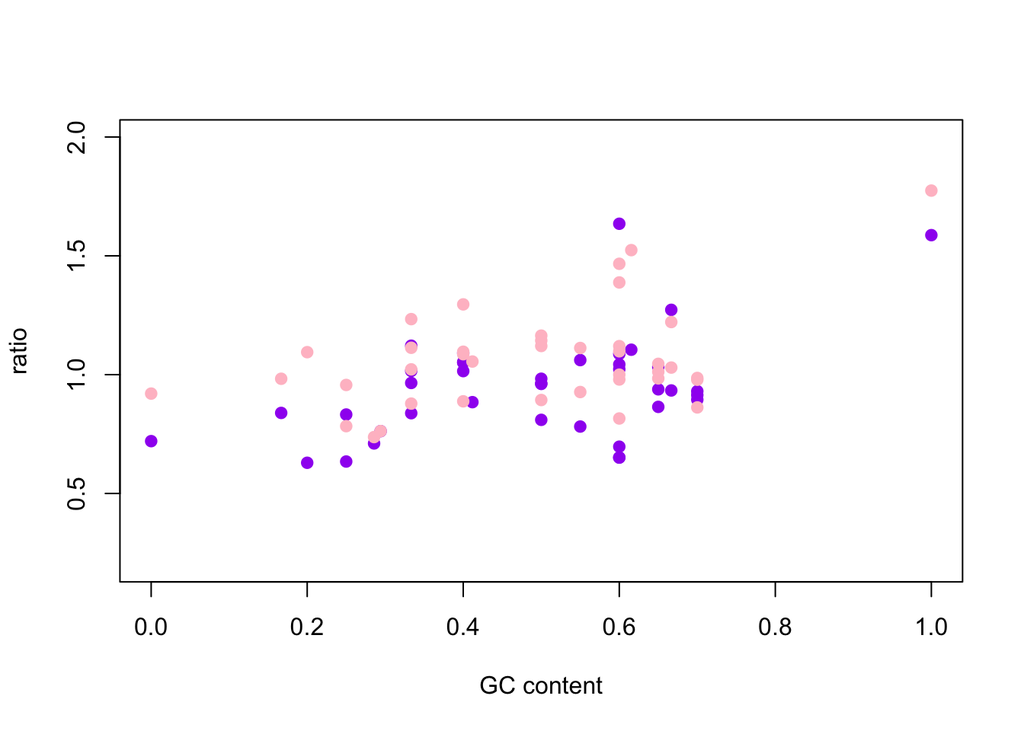

```r
plot(y=C01.comparison_common.kmers, x=common.kmer.gc, type="p", col="purple", pch=19, ylim=c(0.2, 2.0), xlab="GC content", ylab="ratio")
points(y=C35.comparison_common.kmers,x=common.kmer.gc, pch=19, col="pink" )
```

Conclusion: most of the ratios are consistent and close to 1, however there is unpredictable variation for kmers at 60% GC.

## Compare correlation in technical replicates to correlation among MA lines

```r
cor_MAlines <- cor(t(daphniakmers_normalized_w_techrep[, common.kmer.indexes]))
#cor_MAlines
# all MA lines are highly correlated
```

## Do a PCA of the 3 library preps

```r
lib1.lines <- c("C02", "C03", "C06", "C07", "C08", "C12", "C13", "C14", "C16", "C17", "C18", "C20", "C21", "C24", "C25", "C34", "C36", "C37", "C38", "C39", "C40", "C44")
lib1.indexes <- match(lib1.lines, rownames(daphniakmers_normalized_w_techrep))
lib2.lines <- c("C23", "C27", "C43", "C49", "CC3", "CC4", "CC6", "CC7", "CC8", "CC9")
lib2.indexes <- match(lib2.lines, rownames(daphniakmers_normalized_w_techrep))
C01.index
```

```
## [1] 2
```

```r
C001.index
```

```
## [1] 1
```

```r
C35.index
```

```
## [1] 22
```

```r
C035.index
```

```
## [1] 5
```

```r
lib1.indexes
```

```
##  [1]  3  4  6  7  8  9 10 11 12 13 14 15 16 18 19 21 23 24 25 26 27 29
```

```r
lib2.indexes
```

```
##  [1] 17 20 28 30 31 32 33 34 35 36
```

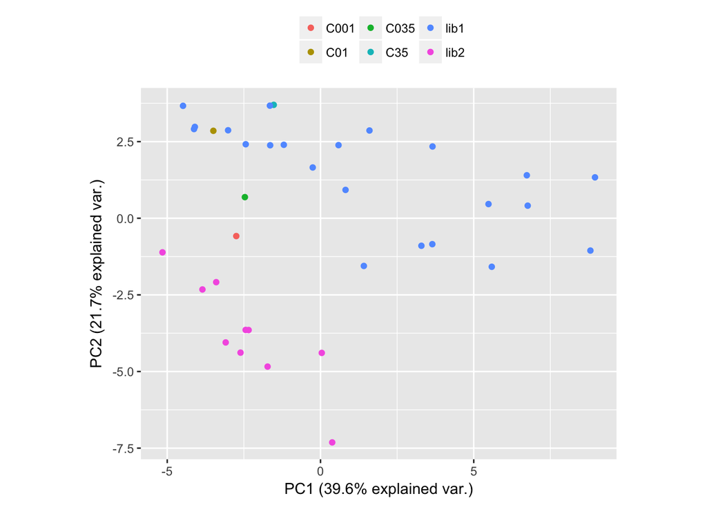

```r
pca.data <- prcomp(daphniakmers_normalized_w_techrep[, common.kmer.indexes], scale.=T)
category <- factor(c( c("C001", "C01", "lib1", "lib1", "C035"), c(rep("lib1",times=11)), "lib2", "lib1", "lib1", "lib2", "lib1", "C35", c(rep("lib1", times=5)), "lib2", "lib1", c(rep("lib2", times=7)) ))

g <- ggbiplot(pca.data, obs.scale = 1, var.scale = 1, groups = category, var.axes = F)
g <- g + scale_color_discrete(name='')
g <- g + theme(legend.direction='horizontal', legend.position='top')
print(g)
```

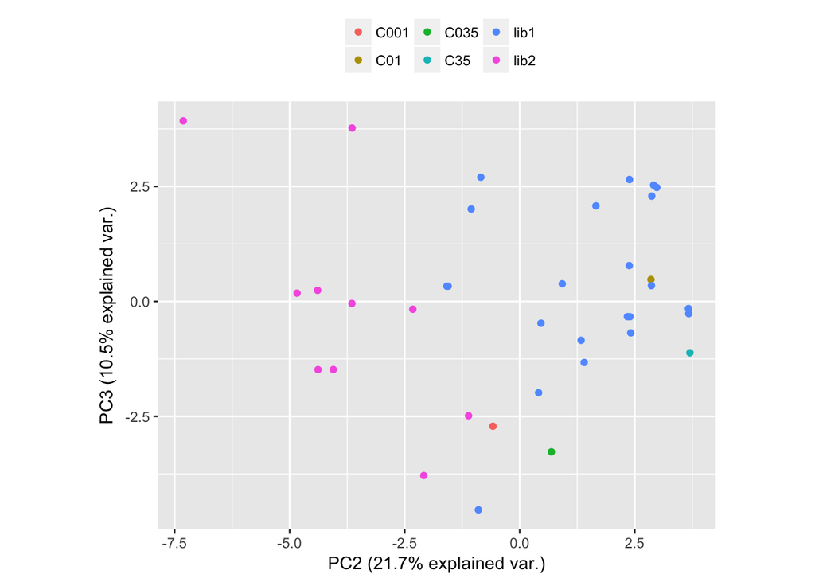

```r
g <- ggbiplot(pca.data, choices=2:3, obs.scale = 1, groups = category, var.scale = 1, var.axes = F)
g <- g + scale_color_discrete(name='')
g <- g + theme(legend.direction='horizontal', legend.position='top')
print(g)
```

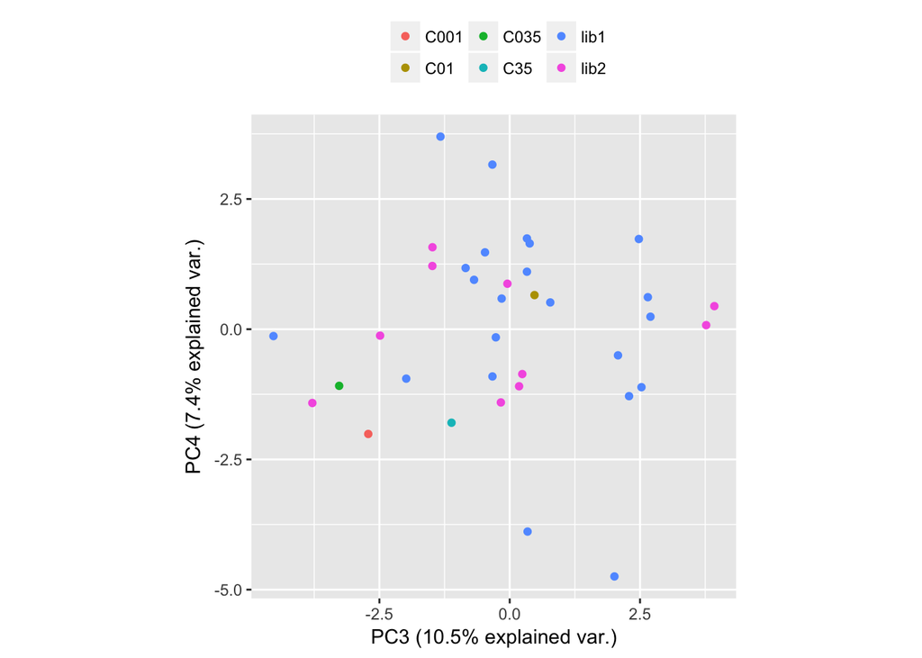

```r
g <- ggbiplot(pca.data, choices=3:4, obs.scale = 1, groups = category, var.scale = 1, var.axes = F)
g <- g + scale_color_discrete(name='')
g <- g + theme(legend.direction='horizontal', legend.position='top')
print(g)
```

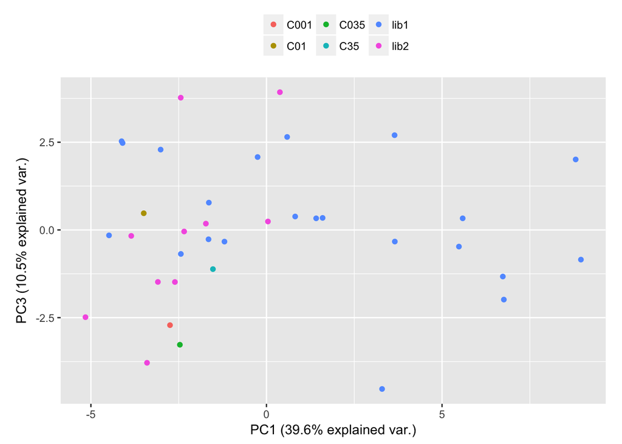

```r
g <- ggbiplot(pca.data, choices=c(1,3), obs.scale = 1, groups = category, var.scale = 1, var.axes = F)
g <- g + scale_color_discrete(name='')
g <- g + theme(legend.direction='horizontal', legend.position='top')
print(g)
```

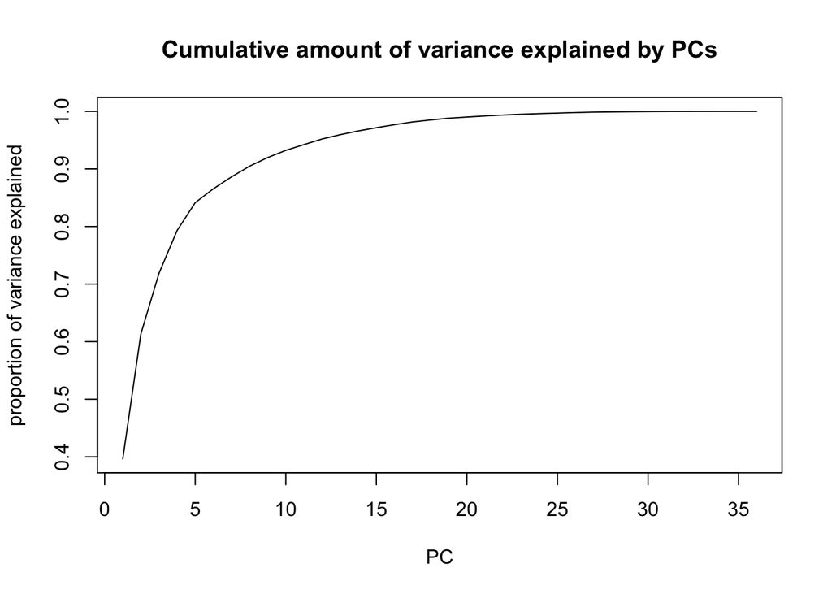

```r
x <- summary(pca.data)
#str(x)
plot(x$importance[3,], type="l", xlab="PC", ylab="proportion of variance explained", main="Cumulative amount of variance explained by PCs")
```

Conclusion: PC1 is separating samples based on a biological factor (mutations). PC2 is separating samples based on library prep. Technical replicates are very close along PC1 and a bit separated along PC2.

## Use permutations to see if there is a significant difference in the abundance of each kmer for the different libraries

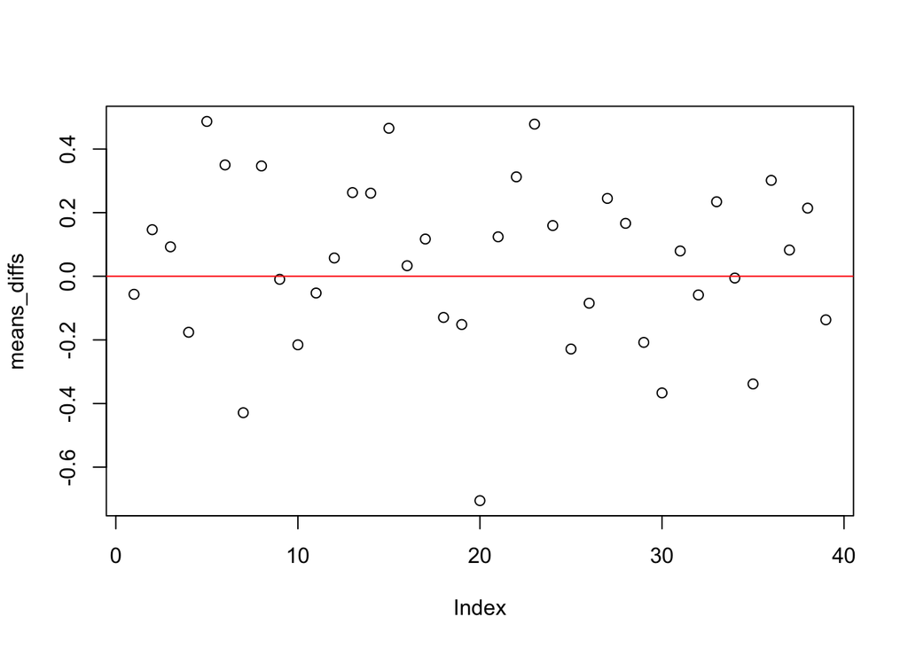

```r
MA1_names <- c("C01", "C02", "C03", "C06", "C07", "C08", "C12", "C13", "C14", "C16", "C17", "C18", "C20", "C21", "C24", "C25", "C34", "C35", "C36", "C37", "C38", "C39", "C40", "C44")
MA1_indexes <- match(MA1_names, rownames(daphniakmers_normalized))
MA2_names <- c("C23", "C27", "C43", "C49")
MA2_indexes <- match(MA2_names, rownames(daphniakmers_normalized))

MA1.means <- c()
for (i in common.kmer.indexes) {
  MA1.means <- c(MA1.means, mean(daphniakmers_normalized[MA1_indexes,i]))
}
MA2.means <- c()
for (i in common.kmer.indexes) {
  MA2.means <- c(MA2.means, mean(daphniakmers_normalized[MA2_indexes,i]))
}

# calculate differences in the means of MA1 and MA2
means_diffs <- (MA1.means - MA2.means)/MA1.means
plot(means_diffs)
abline(h=0, col="red")
```

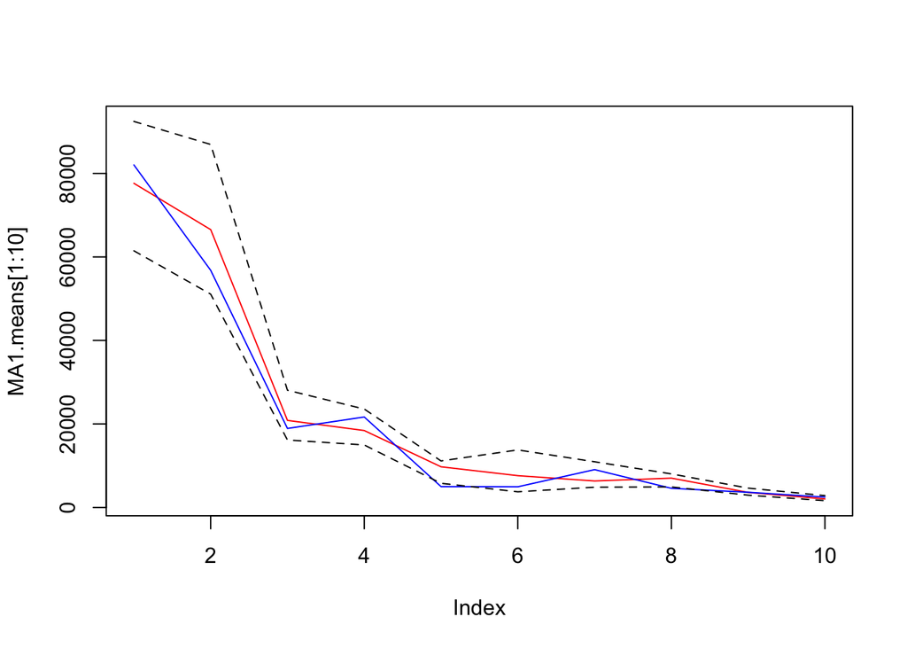

```r
## randomly sample 4 of the 28 and calculate the mean. Do this 1000 times for each kmer.
# calculate the 0.95 and 0.05 quantile of the distribution.
#If the 95% CI is wider than the difference between them, then good.
Calc_CI <- function (kmer_index) {
  means <- c()
  for (j in 1:1000) {
    k <- sample(c(1:24), size=4, replace=T)
    means <- c(means, daphniakmers_normalized[k, kmer_index])
  }
  quantiles <- quantile(means, c(0.05, 0.95))
  return(quantiles)
}


lower_CIs <- c()
for (i in common.kmer.indexes) {
  lower_CIs <- c(lower_CIs, Calc_CI(i)[1])
}

upper_CIs <- c()
for (i in common.kmer.indexes) {
  upper_CIs <- c(upper_CIs, Calc_CI(i)[2])
}

plot(MA1.means[1:10], type="l", col="red", ylim=c( min(lower_CIs[1:10]), max(upper_CIs[1:10])))
lines(MA2.means[1:10], col="blue")
lines (lower_CIs[1:10], lty=2)
lines (upper_CIs[1:10], lty=2)
```

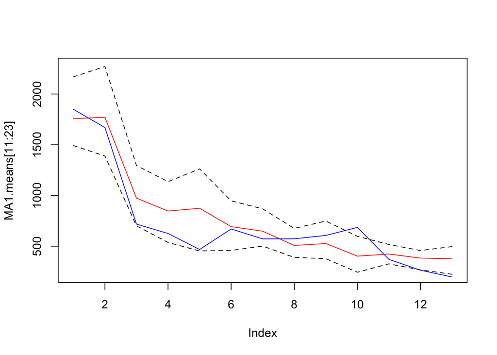

```r
plot(MA1.means[11:23], type="l", col="red", ylim=c( min(lower_CIs[11:23]), max(upper_CIs[11:23])))
lines(MA2.means[11:23], col="blue")
lines (lower_CIs[11:23], lty=2)
lines (upper_CIs[11:23], lty=2)
```

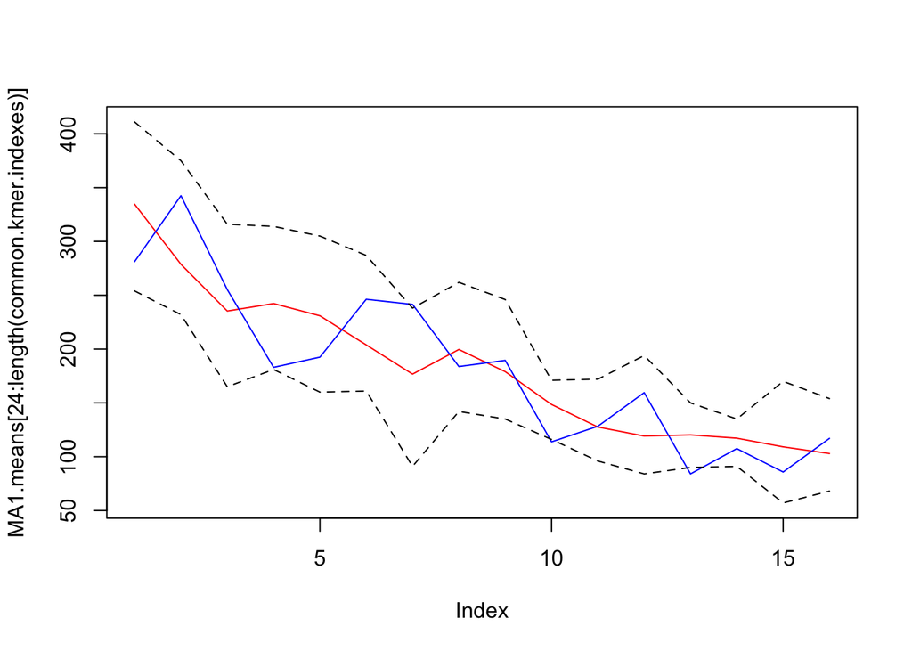

```r
plot(MA1.means[24:length(common.kmer.indexes)], type="l", col="red", ylim=c( min(lower_CIs[24:length(common.kmer.indexes)]), max(upper_CIs[24:length(common.kmer.indexes)])))
lines(MA2.means[24:length(common.kmer.indexes)], col="blue")
lines (lower_CIs[24:length(common.kmer.indexes)], lty=2)
lines (upper_CIs[24:length(common.kmer.indexes)], lty=2)
```

```r
v <- c()
for (i in common.kmer.indexes) {
  v <-  c(v, (min(MA1.means[i], MA2.means[i]) > (Calc_CI(i)[1])) & (max(MA1.means[i], MA2.means[i]) < (Calc_CI(i)[2])))
}
sum(v==TRUE)
```

```
## [1] 31
```

## Is the variation between technical replicates less than the variation between samples?

```r
# try a paired wilcoxon signed test

C01.C001.df <- data.frame(daphniakmers_normalized_w_techrep[C01.index, common.kmer.indexes], daphniakmers_normalized_w_techrep[C001.index, common.kmer.indexes])
colnames(C01.C001.df) <- c("C01", "C001")

wilcox.test(C01.C001.df$C01, C01.C001.df$C001, paired = TRUE)
```

```
##
##  Wilcoxon signed rank test with continuity correction
##
## data:  C01.C001.df$C01 and C01.C001.df$C001
## V = 273.5, p-value = 0.1055
## alternative hypothesis: true location shift is not equal to 0
```

```r
C35.C035.df <- data.frame(daphniakmers_normalized_w_techrep[C35.index, common.kmer.indexes], daphniakmers_normalized_w_techrep[C035.index, common.kmer.indexes])
colnames(C35.C035.df) <- c("C35", "C035")

wilcox.test(C35.C035.df$C35, C35.C035.df$C035, paired = TRUE)
```

```
##
##  Wilcoxon signed rank test with continuity correction
##
## data:  C35.C035.df$C35 and C35.C035.df$C035
## V = 425, p-value = 0.4335
## alternative hypothesis: true location shift is not equal to 0
```

```r
# not significant difference between technical replicates

# significant difference between these two MA lines in the same technical replicate.
# do pairwise comparisons of MA lines??

C01.C35.df <- data.frame(daphniakmers_normalized_w_techrep[C01.index, common.kmer.indexes], daphniakmers_normalized_w_techrep[C35.index, common.kmer.indexes])
colnames(C01.C35.df) <- c("C01", "C35")

result <- wilcox.test(C01.C35.df$C01, C01.C35.df$C35, paired = TRUE)
result$p.value
```

```
## [1] 0.0001998642
```

```r
C001.C035.df <- data.frame(daphniakmers_normalized_w_techrep[C001.index, common.kmer.indexes], daphniakmers_normalized_w_techrep[C035.index, common.kmer.indexes])
colnames(C001.C035.df) <- c("C001", "C035")

result <- wilcox.test(C001.C035.df$C001, C001.C035.df$C035, paired = TRUE)
result$p.value
```

```
## [1] 0.3390905
```

```r
result
```

```
##
##  Wilcoxon signed rank test with continuity correction
##
## data:  C001.C035.df$C001 and C001.C035.df$C035
## V = 459, p-value = 0.3391
## alternative hypothesis: true location shift is not equal to 0
```

```r
wilcoxp_matrix <- matrix(ncol=nrow(daphniakmers_normalized_w_techrep), nrow=nrow(daphniakmers_normalized_w_techrep))

for (i in 1:nrow(daphniakmers_normalized_w_techrep)) {
  for (j in 1:nrow(daphniakmers_normalized_w_techrep)) {
    df <- data.frame(daphniakmers_normalized_w_techrep[i, common.kmer.indexes], daphniakmers_normalized_w_techrep[j, common.kmer.indexes])
    result <- wilcox.test(df[,1], df[,2], paired = TRUE)
    wilcoxp_matrix[i,j] <- result$p.value
  }
}
```

[output not shown]

[output not shown]

[output not shown]

[output not shown]

[output not shown]

[output not shown]

[output not shown]

[output not shown]

[output not shown]

[output not shown]

[output not shown]

[output cut: 28 more lines]

[output not shown]

[output not shown]

[output not shown]

[output not shown]

[output not shown]

[output not shown]

[output not shown]

[output cut: 10 more lines]

[output not shown]

[output not shown]

[output not shown]

[output not shown]

[output not shown]

[output not shown]

[output not shown]

[output not shown]

[output not shown]

[output not shown]

[output not shown]

[output not shown]

[output not shown]

[output not shown]

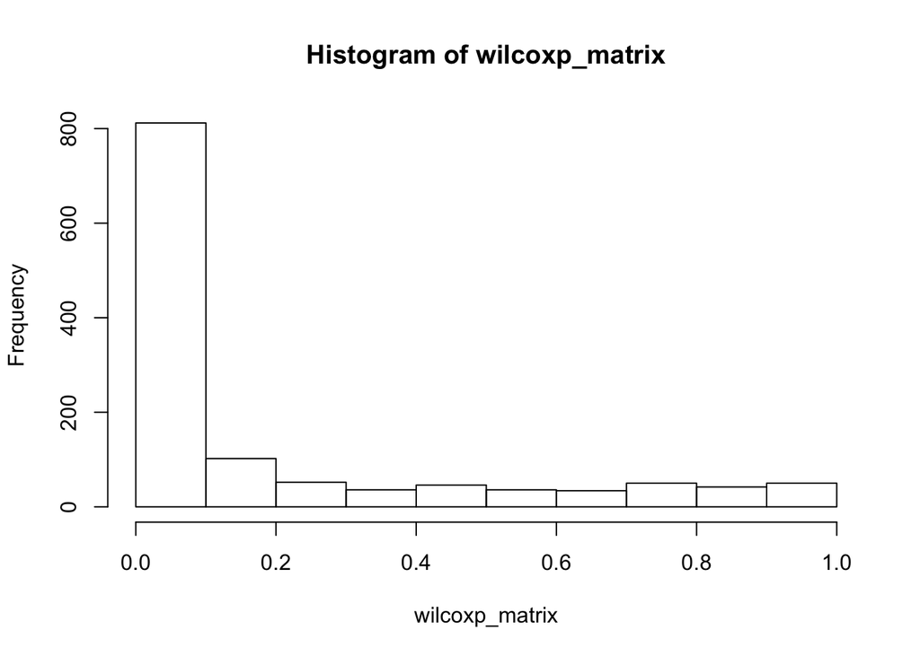

```r
hist(wilcoxp_matrix)
```

```r
alpha <- 0.05/(nrow(wilcoxp_matrix) -1)
alpha
```

```
## [1] 0.001428571
```

```r
length(which(wilcoxp_matrix < 0.05))
```

```
## [1] 700
```